```python
import pandas as pd
import numpy as np
import matplotlib.pyplot as plt
from copy import deepcopy
import seaborn as sns
from scipy.special import expit
import sys
import os
from sklearn.preprocessing import OneHotEncoder
import optuna
from optuna.visualization import plot_contour
from optuna.visualization import plot_edf
from optuna.visualization import plot_intermediate_values
from optuna.visualization import plot_optimization_history
from optuna.visualization import plot_parallel_coordinate
from optuna.visualization import plot_param_importances
from optuna.visualization import plot_slice
from sklearn.pipeline import Pipeline
from sklearn.preprocessing import MinMaxScaler
from sklearn.preprocessing import StandardScaler
from sklearn.metrics import classification_report
from sklearn.pipeline import Pipeline
plt.style.use('ggplot')
```

# Load, Split, and Balance

```python
# load the data into memory
data = pd.read_csv('acs2017_census_tract_data.csv')
# save it to a pandas data frame
rawdf = pd.DataFrame(data)
pd.set_option('display.max_columns', 40)
rawdf.head()
```

|  | TractId | State | County | TotalPop | Men | Women | Hispanic | White | Black | Native | Asian | Pacific | VotingAgeCitizen | Income | IncomeErr | IncomePerCap | IncomePerCapErr | Poverty | ChildPoverty | Professional | Service | Office | Construction | Production | Drive | Carpool | Transit | Walk | OtherTransp | … |
| --- | --- | --- | --- | --- | --- | --- | --- | --- | --- | --- | --- | --- | --- | --- | --- | --- | --- | --- | --- | --- | --- | --- | --- | --- | --- | --- | --- | --- | --- | --- |
| 0 | 1001020100 | Alabama | Autauga County | 1845 | 899 | 946 | 2.4 | 86.3 | 5.2 | 0.0 | 1.2 | 0.0 | 1407 | 67826.0 | 14560.0 | 33018.0 | 6294.0 | 10.7 | 20.8 | 38.5 | 15.6 | 22.8 | 10.8 | 12.4 | 94.2 | 3.3 | 0.0 | 0.5 | 0.0 | … |
| 1 | 1001020200 | Alabama | Autauga County | 2172 | 1167 | 1005 | 1.1 | 41.6 | 54.5 | 0.0 | 1.0 | 0.0 | 1652 | 41287.0 | 3819.0 | 18996.0 | 2453.0 | 22.4 | 35.8 | 30.5 | 24.9 | 22.9 | 6.3 | 15.4 | 90.5 | 9.1 | 0.0 | 0.0 | 0.5 | … |
| 2 | 1001020300 | Alabama | Autauga County | 3385 | 1533 | 1852 | 8.0 | 61.4 | 26.5 | 0.6 | 0.7 | 0.4 | 2480 | 46806.0 | 9496.0 | 21236.0 | 2562.0 | 14.7 | 21.1 | 27.9 | 19.4 | 33.3 | 9.9 | 9.6 | 88.3 | 8.4 | 0.0 | 1.0 | 0.8 | … |
| 3 | 1001020400 | Alabama | Autauga County | 4267 | 2001 | 2266 | 9.6 | 80.3 | 7.1 | 0.5 | 0.2 | 0.0 | 3257 | 55895.0 | 4369.0 | 28068.0 | 3190.0 | 2.3 | 1.7 | 29.0 | 16.6 | 25.8 | 9.1 | 19.5 | 82.3 | 11.2 | 0.0 | 1.5 | 2.9 | … |
| 4 | 1001020500 | Alabama | Autauga County | 9965 | 5054 | 4911 | 0.9 | 77.5 | 16.4 | 0.0 | 3.1 | 0.0 | 7229 | 68143.0 | 14424.0 | 36905.0 | 10706.0 | 12.2 | 17.9 | 48.8 | 13.8 | 20.5 | 3.5 | 13.4 | 86.9 | 11.2 | 0.0 | 0.8 | 0.3 | … |

```python
# describe data and get some info on it
rawdf.describe()
```

|  | TractId | TotalPop | Men | Women | Hispanic | White | Black | Native | Asian | Pacific | VotingAgeCitizen | Income | IncomeErr | IncomePerCap | IncomePerCapErr | Poverty | ChildPoverty | Professional | Service | Office | Construction | Production | Drive | Carpool | Transit | Walk | OtherTransp | WorkAtHome | MeanCommute | … |
| --- | --- | --- | --- | --- | --- | --- | --- | --- | --- | --- | --- | --- | --- | --- | --- | --- | --- | --- | --- | --- | --- | --- | --- | --- | --- | --- | --- | --- | --- | --- |
| count | 7.400100e+04 | 74001.000000 | 74001.000000 | 74001.000000 | 73305.000000 | 73305.000000 | 73305.00000 | 73305.000000 | 73305.000000 | 73305.000000 | 74001.000000 | 72885.000000 | 72885.000000 | 73256.000000 | 73256.000000 | 73159.000000 | 72891.000000 | 73190.000000 | 73190.000000 | 73190.000000 | 73190.000000 | 73190.000000 | 73200.000000 | 73200.000000 | 73200.000000 | 73200.000000 | 73200.000000 | 73200.000000 | 73055.000000 | … |
| mean | 2.839113e+10 | 4384.716017 | 2157.710707 | 2227.005311 | 17.265444 | 61.309043 | 13.28910 | 0.734047 | 4.753691 | 0.147341 | 3102.885961 | 61086.829265 | 9697.465747 | 30651.804194 | 4270.174225 | 16.118186 | 21.155872 | 35.559478 | 18.874446 | 23.427724 | 9.239350 | 12.899281 | 75.698005 | 9.308369 | 5.395186 | 3.042825 | 1.894605 | 4.661466 | 26.056594 | … |
| std | 1.647593e+10 | 2228.936729 | 1120.560504 | 1146.240218 | 23.073811 | 30.634461 | 21.60118 | 4.554247 | 8.999888 | 1.029250 | 1542.245024 | 30516.098180 | 6154.669518 | 16126.937143 | 3148.049041 | 12.691045 | 18.645759 | 15.144984 | 8.137261 | 5.806091 | 6.031393 | 7.712496 | 15.292660 | 5.222494 | 11.689470 | 5.805753 | 2.549374 | 4.014940 | 7.124524 | … |
| min | 1.001020e+09 | 0.000000 | 0.000000 | 0.000000 | 0.000000 | 0.000000 | 0.00000 | 0.000000 | 0.000000 | 0.000000 | 0.000000 | 2692.000000 | 728.000000 | 32.000000 | 20.000000 | 0.000000 | 0.000000 | 0.000000 | 0.000000 | 0.000000 | 0.000000 | 0.000000 | 0.000000 | 0.000000 | 0.000000 | 0.000000 | 0.000000 | 0.000000 | 1.000000 | … |
| 25% | 1.303901e+10 | 2903.000000 | 1416.000000 | 1465.000000 | 2.600000 | 38.000000 | 0.80000 | 0.000000 | 0.200000 | 0.000000 | 2061.000000 | 40357.000000 | 5735.000000 | 20556.750000 | 2503.000000 | 6.900000 | 6.200000 | 24.700000 | 13.300000 | 19.700000 | 5.000000 | 7.100000 | 72.200000 | 5.700000 | 0.000000 | 0.400000 | 0.400000 | 2.000000 | 21.100000 | … |
| 50% | 2.804700e+10 | 4105.000000 | 2007.000000 | 2082.000000 | 7.400000 | 70.400000 | 3.80000 | 0.000000 | 1.500000 | 0.000000 | 2905.000000 | 54375.000000 | 8267.000000 | 27215.500000 | 3404.000000 | 12.600000 | 16.300000 | 33.300000 | 17.700000 | 23.200000 | 8.300000 | 11.800000 | 79.900000 | 8.500000 | 1.000000 | 1.400000 | 1.200000 | 3.800000 | 25.400000 | … |
| 75% | 4.200341e+10 | 5506.000000 | 2707.000000 | 2803.000000 | 21.100000 | 87.700000 | 14.60000 | 0.400000 | 5.000000 | 0.000000 | 3906.000000 | 74659.000000 | 11913.000000 | 36408.250000 | 4968.250000 | 21.800000 | 31.600000 | 44.900000 | 23.300000 | 26.900000 | 12.500000 | 17.500000 | 84.900000 | 11.900000 | 4.600000 | 3.300000 | 2.500000 | 6.300000 | 30.300000 | … |
| max | 7.215375e+10 | 65528.000000 | 32266.000000 | 33262.000000 | 100.000000 | 100.000000 | 100.00000 | 100.000000 | 100.000000 | 71.900000 | 39389.000000 | 249750.000000 | 153365.000000 | 220253.000000 | 134017.000000 | 100.000000 | 100.000000 | 100.000000 | 100.000000 | 100.000000 | 100.000000 | 100.000000 | 100.000000 | 100.000000 | 100.000000 | 100.000000 | 100.000000 | 100.000000 | 73.900000 | … |

```python
rawdf.info()
```

```
<class 'pandas.core.frame.DataFrame'>
RangeIndex: 74001 entries, 0 to 74000
Data columns (total 37 columns):
 #   Column            Non-Null Count  Dtype
---  ------            --------------  -----
 0   TractId           74001 non-null  int64
 1   State             74001 non-null  object
 2   County            74001 non-null  object
 3   TotalPop          74001 non-null  int64
 4   Men               74001 non-null  int64
 5   Women             74001 non-null  int64
 6   Hispanic          73305 non-null  float64
 7   White             73305 non-null  float64
 8   Black             73305 non-null  float64
 9   Native            73305 non-null  float64
```

[output cut: 29 more lines]

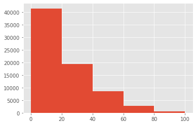

```python
# remove missing data
rawdf.dropna(inplace = True)

rawdf.ChildPoverty.hist(bins=5)
```

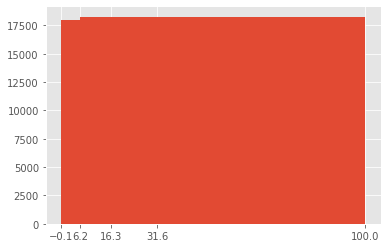

```python
# now make a copy, sorted based on child poverty, and split based on indexing
rawdf.sort_values(by=['ChildPoverty'] ,inplace = True)
idx=rawdf.columns.get_loc("ChildPoverty")

plt.figure()

bins_ = [-0.1, rawdf.iloc[18179, idx], rawdf.iloc[36359, idx], rawdf.iloc[54539, idx], rawdf.iloc[72717, idx]]
rawdf.ChildPoverty.hist(bins=bins_)
plt.xticks(bins_)
plt.show()
```

```python
#copy the dataframe
df = deepcopy(rawdf)

#save the encoding for states and county and replace string to int
State_type = dict(zip(rawdf.State.unique(),range(1,len(rawdf.State.unique())+1)))

df.State.replace(to_replace = State_type.keys(), value = State_type.values(), inplace = True)

County_type = dict(zip(rawdf.County.unique(),range(1,len(rawdf.County.unique())+1)))

df.County.replace(to_replace = County_type.keys(), value = County_type.values(), inplace = True)

#add a column for encoded child poverty
#first bin is neg. so that 0 is included
bins_ = [-0.1, rawdf.iloc[18179, idx], rawdf.iloc[36359, idx], rawdf.iloc[54539, idx], rawdf.iloc[72717, idx]]
ChildPoverty = rawdf.ChildPoverty
ChildPoverty_incode = pd.cut(ChildPoverty,bins_,labels=False)
df['ChildPoverty_'] = ChildPoverty_incode

#drop columns
df = df.drop(['TractId','ChildPoverty'], axis=1)
```

```python
print(rawdf.iloc[18179, idx])
print(rawdf.iloc[36359, idx])
print(rawdf.iloc[54539, idx])
print(rawdf.iloc[72717, idx])
```

```
6.2
16.3
31.6
100.0
```

So now all of the data is loaded into the dataframe and we have separated the dataset into 4 equal categories, as plotted above. The string data is all encoded as integers as well. Now to split the dataset into a testing set and a training set with a 20%/80% split, respectively. First, we are going to one hot encode the target, but not the categorical data until later in the lab.

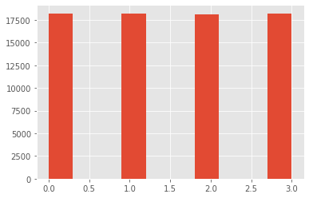

```python
df.ChildPoverty_.hist()
```

As you can see, our balancing worked well enough so that every category has an equal amount of instances. We discuss later on, at the bottom of this section, why we chose our particular method for balancing the dataset.

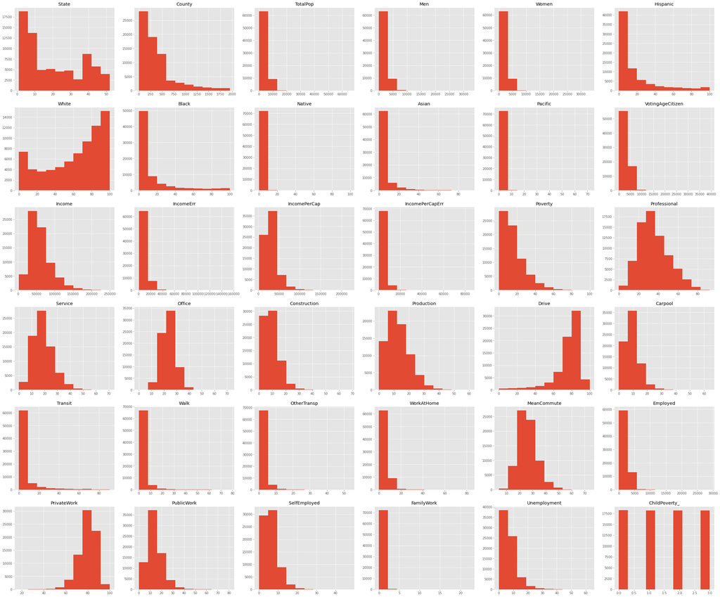

```python
# plot data to better visualize it
plt.figure(figsize=(40,40))
for i,c in enumerate(df.columns):
    plt.subplot(7,6,i+1)
    df[c].hist()
    plt.title(c)
plt.show()
```

```python
from sklearn.model_selection import train_test_split
target = df.pop('ChildPoverty_')
X_train, X_test, y_train, y_test = train_test_split(df, target, test_size=0.20,stratify=target, random_state=42)
```

Below, we demonstrate how many instances of each class are in both the training and testing set. As you can see, they are all around roughly the same size in both sets.

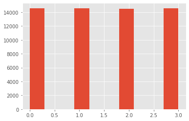

```python
y_train.hist()
```

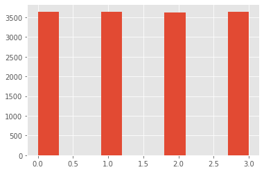

```python
y_test.hist()
```

**Our method for balancing dataset and justification**

**Should balancing of the dataset be done for both the training and testing set?**

Yes and no. It depends on how you define balancing. In our case, we decided to balance the dataset into classes, not by creating new samples of underrepresented data or deleting overrepresented data, but by separating the existing data into even groups. In this case, yes, you want to do it for both the training and testing sets, so that they are encoded in similar ways and there is no confusion in the classifier. However, there is also the possibility that by 'balancing' you mean deleting overrepresented data or increasing underrepresented data. The requirement was sort of unclear in that general area, but if this was the intention, then no, you would not balance the dataset in the testing set because you would want to test your algorithm on a testing set that was true-to-life and not manipulated.

# Pre-processing

```python
# Using examples from class
class TwoLayerPerceptronBase(object): #MSE loss
    def __init__(self, n_hidden=5,
                 C=0.0, epochs=500, eta=0.001, random_state=None):
        np.random.seed(random_state)
        self.n_hidden = n_hidden
        self.l2_C = C
        self.epochs = epochs
        self.eta = eta

    @staticmethod
    def _encode_labels(y):
        """Encode labels into one-hot representation"""
        onehot = pd.get_dummies(y).values.T

        return onehot

    def _initialize_weights(self):
        """Initialize weights with small random numbers."""
        W1_num_elems = (self.n_features_)*self.n_hidden
        W1 = np.random.uniform(-1.0, 1.0, size=W1_num_elems)
        W1 = W1.reshape(self.n_hidden, self.n_features_) # reshape to be W
        b1 = np.zeros((self.n_hidden, 1))

        W2_num_elems = (self.n_hidden)*self.n_output_
        W2 = np.random.uniform(-1.0, 1.0, size=W2_num_elems)
        W2 = W2.reshape(self.n_output_, self.n_hidden)
        b2 = np.zeros((self.n_output_, 1))

        return W1, W2, b1, b2

    @staticmethod
    def _sigmoid(z):
        """Use scipy.special.expit to avoid overflow"""
        # 1.0 / (1.0 + np.exp(-z))
        return expit(z)


    @staticmethod
    def _L2_reg(lambda_, W1, W2):
        """Compute L2-regularization cost"""
        # only compute for non-bias terms
        return (lambda_/2.0) * np.sqrt(np.mean(W1[:, 1:] ** 2) + np.mean(W2[:, 1:] ** 2))

    def _cost(self,A3,Y_enc,W1,W2):
        '''Get the objective function value'''
        cost = np.mean((Y_enc-A3)**2)
        L2_term = self._L2_reg(self.l2_C, W1, W2)
        return cost + L2_term

    def _feedforward(self, X, W1, W2, b1, b2):
        """Compute feedforward step
        -----------
        X : Input layer with original features.
        W1: Weight matrix for input layer -> hidden layer.
        W2: Weight matrix for hidden layer -> output layer.
        ----------
        a1-a3 : activations into layer (or output layer)
        z1-z2 : layer inputs

        """
        A1 = X.T
        Z1 = W1 @ A1 + b1

        A2 = self._sigmoid(Z1)

        Z2 = W2 @ A2 + b2

        A3 = self._sigmoid(Z2)
        #
        #Z3 = W3 @ A3 + b3

        return A1, Z1, A2, Z2, A3

    def _get_gradient(self, A1, A2, A3, Z1, Z2, Y_enc, W1, W2):
        """ Compute gradient step using backpropagation.
        """
        # vectorized backpropagation
        V2 = -2*(Y_enc-A3)*A3*(1-A3)
        V1 = A2*(1-A2)*(W2.T @ V2)

        gradW2 = V2 @ A2.T
        gradW1 = V1 @ A1.T

        gradb2 = np.sum(V2, axis=1).reshape((-1,1))
        gradb1 = np.sum(V1, axis=1).reshape((-1,1))


        # regularize weights that are not bias terms
        gradW1 += W1 * self.l2_C
        gradW2 += W2 * self.l2_C

        return gradW1, gradW2, gradb1, gradb2

    def predict(self, X):
        """Predict class labels"""
        _, _, _, _, A3 = self._feedforward(X, self.W1, self.W2, self.b1, self.b2)

        # assert False, A3.shape

        y_pred = np.argmax(A3, axis=0)
        return y_pred
```

```python
from sklearn.metrics import accuracy_score
# just start with the vectorized version and minibatch
class TLPMiniBatch(TwoLayerPerceptronBase):  #MSE loss
    def __init__(self, alpha=0.0, decrease_const=0.1,
                 decrease_iter = 10, shuffle=True,
                 minibatches=1, **kwds):
        # need to add to the original initializer
        self.alpha = alpha
        self.decrease_const = decrease_const
        self.decrease_iter = decrease_iter
        self.shuffle = shuffle
        self.minibatches = minibatches
        # but keep other keywords
        super().__init__(**kwds)


    def fit(self, X, y, print_progress=False, XY_test=None):
        """ Learn weights from training data. With mini-batch"""
        X_data, y_data = X.copy(), y.copy()
        Y_enc = self._encode_labels(y)

        # init weights and setup matrices
        self.n_features_ = X_data.shape[1]
        self.n_output_ = Y_enc.shape[0]
        self.W1, self.W2, self.b1, self.b2 = self._initialize_weights()

        # start momentum at zero for previous updates
        rho_W1_prev = np.zeros(self.W1.shape) # for momentum
        rho_W2_prev = np.zeros(self.W2.shape) # for momentum

        self.cost_ = []
        self.score_ = []
        # get starting acc
        self.score_.append(accuracy_score(y_data,self.predict(X_data)))

        # keep track of validation, if given
        if XY_test is not None:
            X_test = XY_test[0].copy()
            y_test = XY_test[1].copy()
            self.val_score_ = []
            self.val_score_.append(accuracy_score(y_test,self.predict(X_test)))
            self.val_cost_ = []

        for i in range(self.epochs):

            # adaptive learning rate
            # decrease at certain epochs
            eta = self.eta * self.decrease_const**(np.floor(i/self.decrease_iter))

            if print_progress>0 and (i+1)%print_progress==0:
                sys.stderr.write('\rEpoch: %d/%d' % (i+1, self.epochs))
                sys.stderr.flush()

            if self.shuffle:
                idx_shuffle = np.random.permutation(y_data.shape[0])
                X_data, Y_enc, y_data = X_data[idx_shuffle], Y_enc[:, idx_shuffle], y_data[idx_shuffle]

            mini = np.array_split(range(y_data.shape[0]), self.minibatches)
            mini_cost = []
            for idx in mini:

                # feedforward
                A1, Z1, A2, Z2, A3 = self._feedforward(X_data[idx],
                                                       self.W1,
                                                       self.W2,
                                                       self.b1,
                                                       self.b2
                                                      )

                cost = self._cost(A3,Y_enc[:, idx],self.W1,self.W2)
                mini_cost.append(cost) # this appends cost of mini-batch only

                # compute gradient via backpropagation
                gradW1, gradW2, gradb1, gradb2 = self._get_gradient(A1=A1, A2=A2, A3=A3, Z1=Z1, Z2=Z2,
                                                  Y_enc=Y_enc[:, idx],
                                                  W1=self.W1,W2=self.W2)

                # momentum calculations
                rho_W1, rho_W2 = eta * gradW1, eta * gradW2
                self.W1 -= (rho_W1 + (self.alpha * rho_W1_prev)) # update with momentum
                self.W2 -= (rho_W2 + (self.alpha * rho_W2_prev)) # update with momentum
                self.b1 -= eta * gradb1
                self.b2 -= eta * gradb2
                rho_W1_prev, rho_W2_prev = rho_W1, rho_W2


            self.cost_.append(np.mean(mini_cost))
            self.score_.append(accuracy_score(y_data,self.predict(X_data)))
            if XY_test is not None:
                yhat = self.predict(X_test)
                self.val_score_.append(accuracy_score(y_test,yhat))

        return self
```

```python
# to implement the new style of objective function,
# we just need to update the final layer calculation of the gradient
class TLPMiniBatchCrossEntropy(TLPMiniBatch):  #CrossEntropy loss
    def _cost(self,A3,Y_enc,W1,W2):
        '''Get the objective function value'''
        cost = -np.mean(np.nan_to_num((Y_enc*np.log(A3)+(1-Y_enc)*np.log(1-A3))))
        L2_term = self._L2_reg(self.l2_C, W1, W2)
        return cost + L2_term

    def _get_gradient(self, A1, A2, A3, Z1, Z2, Y_enc, W1, W2):
        """ Compute gradient step using backpropagation.
        """
        # vectorized backpropagation
        V2 = (A3-Y_enc) # <- this is only line that changed
        V1 = A2*(1-A2)*(W2.T @ V2)

        gradW2 = V2 @ A2.T
        gradW1 = V1 @ A1.T

        gradb2 = np.sum(V2, axis=1).reshape((-1,1))
        gradb1 = np.sum(V1, axis=1).reshape((-1,1))

        # regularize weights that are not bias terms
        gradW1 += W1 * self.l2_C
        gradW2 += W2 * self.l2_C

        return gradW1, gradW2, gradb1, gradb2
```

```python
class TLPBetterInitialCrossEntropy(TLPMiniBatchCrossEntropy):   #CrossEntropy loss
    def _initialize_weights(self):
        """Initialize weights Glorot and He normalization."""
        init_bound = 4*np.sqrt(6. / (self.n_hidden + self.n_features_))
        W1 = np.random.uniform(-init_bound, init_bound,(self.n_hidden, self.n_features_))

        # reduce the final layer magnitude in order to balance the size of the gradients
        # between
        init_bound = 4*np.sqrt(6 / (self.n_output_ + self.n_hidden))
        W2 = np.random.uniform(-init_bound, init_bound,(self.n_output_, self.n_hidden))

        b1 = np.zeros((self.n_hidden, 1))
        b2 = np.zeros((self.n_output_, 1))

        return W1, W2, b1, b2
```

```python
class TLPBetterInitialMSE(TLPMiniBatch):   #MSE loss
    def _initialize_weights(self):
        """Initialize weights Glorot and He normalization."""
        init_bound = 4*np.sqrt(6. / (self.n_hidden + self.n_features_))
        W1 = np.random.uniform(-init_bound, init_bound,(self.n_hidden, self.n_features_))

        # reduce the final layer magnitude in order to balance the size of the gradients
        # between
        init_bound = 4*np.sqrt(6 / (self.n_output_ + self.n_hidden))
        W2 = np.random.uniform(-init_bound, init_bound,(self.n_output_, self.n_hidden))

        b1 = np.zeros((self.n_hidden, 1))
        b2 = np.zeros((self.n_output_, 1))

        return W1, W2, b1, b2
```

```python
def print_result(nn,X_train,y_train,X_test,y_test,title="",color="red"):

    print("=================")
    print(title,":")
    yhat = nn.predict(X_train)
    print('Resubstitution acc:',accuracy_score(y_train,yhat))

    yhat = nn.predict(X_test)
    print('Validation acc:',accuracy_score(y_test,yhat))

    if hasattr(nn,'val_score_'):
        plt.plot(range(len(nn.val_score_)), nn.val_score_, color=color,label=title)
        plt.ylabel('Validation Accuracy')
    else:
        plt.plot(range(len(nn.score_)), nn.score_, color=color,label=title)
        plt.ylabel('Resub Accuracy')

    plt.xlabel('Epochs')
    plt.tight_layout()
    plt.legend(loc='best')
    plt.grid(True)
```

```python
# no normalization or one hot encoding
import warnings
warnings.filterwarnings("ignore")

vals = { 'n_hidden':15,
         'C':0.1, 'epochs':50, 'eta':0.001,
         'alpha':0.001, 'decrease_const':0.1, 'decrease_iter':15,
         'minibatches':32,
         'shuffle':True}

nn_cross = TLPBetterInitialCrossEntropy(**vals)
nn_mse = TLPBetterInitialMSE(**vals)

%time nn_cross.fit(X_train.to_numpy(), y_train.to_numpy(), print_progress=1, XY_test=(X_test.to_numpy(), y_test.to_numpy()))
%time nn_mse.fit(X_train.to_numpy(), y_train.to_numpy(), print_progress=1, XY_test=(X_test.to_numpy(), y_test.to_numpy()))
```

```
Epoch: 4/500
```

```
CPU times: user 10.1 s, sys: 1.77 s, total: 11.9 s
Wall time: 3.15 s
```

```
Epoch: 50/50
```

```
CPU times: user 9.77 s, sys: 2.01 s, total: 11.8 s
Wall time: 3.72 s
```

```
<__main__.TLPBetterInitialMSE at 0x7f9500e7fbb0>
```

```
=================
CrossEntropy Loss :
Resubstitution acc: 0.2508680853989755
Validation acc: 0.2508250825082508
=================
MSE Loss :
Resubstitution acc: 0.2506618076804071
Validation acc: 0.2506875687568757
```

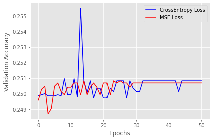

```python
print_result(nn_cross,X_train.to_numpy(), y_train.to_numpy(),X_test.to_numpy(),y_test.to_numpy(),title="CrossEntropy Loss",color="blue")
print_result(nn_mse,X_train.to_numpy(), y_train.to_numpy(),X_test.to_numpy(),y_test.to_numpy(),title="MSE Loss",color="red")
```

X_train showing correct preprocessing for method 1.

```python
X_train
```

|  | State | County | TotalPop | Men | Women | Hispanic | White | Black | Native | Asian | Pacific | VotingAgeCitizen | Income | IncomeErr | IncomePerCap | IncomePerCapErr | Poverty | Professional | Service | Office | Construction | Production | Drive | Carpool | Transit | Walk | OtherTransp | WorkAtHome | MeanCommute | … |
| --- | --- | --- | --- | --- | --- | --- | --- | --- | --- | --- | --- | --- | --- | --- | --- | --- | --- | --- | --- | --- | --- | --- | --- | --- | --- | --- | --- | --- | --- | --- |
| 14779 | 8 | 148 | 2887 | 1426 | 1461 | 5.4 | 89.9 | 0.0 | 1.9 | 0.8 | 0.0 | 2375 | 50536.0 | 11376.0 | 27920.0 | 4199.0 | 14.6 | 19.2 | 24.9 | 25.4 | 14.6 | 15.9 | 86.9 | 11.7 | 0.0 | 0.6 | 0.0 | 0.8 | 35.2 | … |
| 48998 | 3 | 126 | 3245 | 1453 | 1792 | 5.6 | 70.4 | 17.2 | 0.1 | 3.0 | 0.0 | 2753 | 35180.0 | 3246.0 | 27235.0 | 2879.0 | 18.1 | 43.7 | 19.9 | 24.5 | 3.2 | 8.7 | 90.1 | 6.0 | 0.9 | 0.0 | 0.0 | 3.0 | 16.6 | … |
| 34972 | 13 | 35 | 1631 | 883 | 748 | 2.6 | 43.1 | 49.4 | 1.0 | 1.9 | 0.0 | 1295 | 62563.0 | 24700.0 | 31709.0 | 5410.0 | 18.6 | 52.3 | 10.5 | 20.4 | 2.6 | 14.2 | 79.1 | 11.1 | 1.2 | 2.3 | 3.6 | 2.8 | 26.5 | … |
| 7968 | 2 | 47 | 8992 | 4663 | 4329 | 54.9 | 15.2 | 5.9 | 0.6 | 20.7 | 2.4 | 3784 | 49881.0 | 12149.0 | 17516.0 | 2836.0 | 25.5 | 17.6 | 17.9 | 31.2 | 5.5 | 27.8 | 76.6 | 11.5 | 4.6 | 2.2 | 4.7 | 0.4 | 28.9 | … |
| 61217 | 22 | 472 | 791 | 362 | 429 | 6.8 | 7.8 | 85.3 | 0.0 | 0.0 | 0.0 | 453 | 20565.0 | 6851.0 | 8921.0 | 2759.0 | 65.3 | 14.7 | 15.5 | 24.6 | 15.5 | 29.8 | 77.8 | 14.7 | 0.0 | 7.5 | 0.0 | 0.0 | 24.1 | … |
| ... | ... | ... | ... | ... | ... | ... | ... | ... | ... | ... | ... | ... | ... | ... | ... | ... | ... | ... | ... | ... | ... | ... | ... | ... | ... | ... | ... | ... | ... | … |
| 4134 | 2 | 2 | 7469 | 3581 | 3888 | 26.3 | 35.5 | 22.3 | 0.0 | 12.6 | 0.2 | 5198 | 107250.0 | 26164.0 | 35856.0 | 4152.0 | 11.0 | 34.4 | 24.8 | 24.7 | 8.6 | 7.5 | 68.9 | 9.5 | 10.8 | 0.3 | 2.6 | 7.8 | 43.9 | … |
| 54106 | 30 | 239 | 2561 | 1244 | 1317 | 28.9 | 55.2 | 5.6 | 2.5 | 5.1 | 0.0 | 1772 | 73224.0 | 9723.0 | 28093.0 | 2744.0 | 4.3 | 28.9 | 16.1 | 20.3 | 15.1 | 19.5 | 86.5 | 11.8 | 0.0 | 0.0 | 0.0 | 1.8 | 21.2 | … |
| 3601 | 2 | 41 | 5425 | 2678 | 2747 | 6.3 | 67.6 | 2.5 | 0.0 | 17.4 | 0.0 | 4128 | 163464.0 | 27440.0 | 84765.0 | 8532.0 | 5.1 | 71.1 | 9.7 | 16.2 | 0.9 | 2.1 | 62.1 | 2.0 | 18.8 | 0.9 | 3.1 | 13.1 | 36.6 | … |
| 11236 | 2 | 847 | 4555 | 2294 | 2261 | 26.5 | 71.7 | 0.0 | 0.4 | 0.3 | 0.0 | 3100 | 64464.0 | 11512.0 | 32057.0 | 2688.0 | 15.2 | 39.5 | 14.4 | 17.2 | 17.9 | 10.9 | 82.8 | 4.1 | 0.0 | 4.0 | 1.0 | 8.2 | 23.5 | … |
| 32691 | 6 | 6 | 3467 | 1589 | 1878 | 12.3 | 77.6 | 2.7 | 0.0 | 6.1 | 0.0 | 2598 | 93750.0 | 17058.0 | 42017.0 | 4576.0 | 8.6 | 45.7 | 17.3 | 22.7 | 4.6 | 9.7 | 78.6 | 8.8 | 1.6 | 0.5 | 3.6 | 6.9 | 28.1 | … |

58174 rows × 35 columns

As you can see, using the two layer network on data that is neither normalized nor one hot encoded only yields an accuracy of about 25%, so this data does not provide very accurate results. All the variables are scaled differently, and the higher magnitudes of encoded 'State' and 'County' will have higer importance, which is not the behavior we want in this classifier. We would like all of the variables to be scaled the same even with different label encodings.

```python
# normalize continuous data
X_train, X_test, y_train, y_test = train_test_split(df, target, test_size=0.20,stratify=target, random_state=42)


num_var = ['TotalPop', 'Men', 'Women', 'Hispanic', 'White','Black', 'Native', 'Asian', 'Pacific', 'VotingAgeCitizen', 'Income','IncomeErr', 'IncomePerCap', 'IncomePerCapErr', 'Poverty','Professional', 'Service', 'Office', 'Construction', 'Production','Drive', 'Carpool', 'Transit', 'Walk', 'OtherTransp', 'WorkAtHome','MeanCommute', 'Employed', 'PrivateWork', 'PublicWork', 'SelfEmployed','FamilyWork', 'Unemployment']
mmscaler = MinMaxScaler()
num_df = pd.DataFrame(mmscaler.fit_transform(X_train[num_var]),columns=num_var)
num_df['State'] = X_train.pop("State")
num_df['County'] = X_train.pop("County")

vals = { 'n_hidden':30,
         'C':0.1, 'epochs':20, 'eta':0.001, # poor starting learning rate!!
         'alpha':0.001, 'decrease_const':0.1, 'decrease_iter':15,
         'minibatches':50,
         'shuffle':True}

nn_cross = TLPBetterInitialCrossEntropy(**vals)
nn_mse = TLPBetterInitialMSE(**vals)
num_test = mmscaler.transform(X_test[num_var])
num_test=pd.DataFrame(num_test,columns=num_var)
num_test['State'] = X_test.pop('State')
num_test['County'] = X_test.pop('County')

%time nn_cross.fit(num_df.to_numpy(), y_train.to_numpy(), print_progress=1, XY_test=(num_test.to_numpy(), y_test.to_numpy()))
%time nn_mse.fit(num_df.to_numpy(), y_train.to_numpy(), print_progress=1, XY_test=(num_test.to_numpy(), y_test.to_numpy()))
```

```
Epoch: 2/200
```

```
CPU times: user 5.78 s, sys: 1.08 s, total: 6.86 s
Wall time: 1.81 s
```

```
Epoch: 20/20
```

```
CPU times: user 5.44 s, sys: 1 s, total: 6.44 s
Wall time: 1.67 s
```

```
<__main__.TLPBetterInitialMSE at 0x7f9500e7f040>
```

```
=================
CrossEntropy Loss :
Resubstitution acc: 0.25067899749028777
Validation acc: 0.2506875687568757
=================
MSE Loss :
Resubstitution acc: 0.25067899749028777
Validation acc: 0.2506875687568757
```

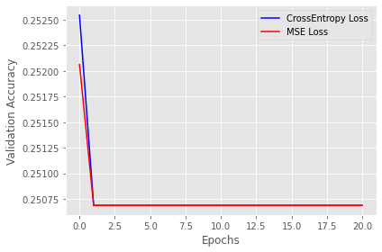

```python
print_result(nn_cross,num_df.to_numpy(), y_train.to_numpy(),num_test.to_numpy(),y_test.to_numpy(),title="CrossEntropy Loss",color="blue")
print_result(nn_mse,num_df.to_numpy(), y_train.to_numpy(),num_test.to_numpy(),y_test.to_numpy(),title="MSE Loss",color="red")
```

X_train showing correct preprocessing for method 2.

```python
num_df
```

|  | TotalPop | Men | Women | Hispanic | White | Black | Native | Asian | Pacific | VotingAgeCitizen | Income | IncomeErr | IncomePerCap | IncomePerCapErr | Poverty | Professional | Service | Office | Construction | Production | Drive | Carpool | Transit | Walk | OtherTransp | WorkAtHome | MeanCommute | Employed | PrivateWork | … |
| --- | --- | --- | --- | --- | --- | --- | --- | --- | --- | --- | --- | --- | --- | --- | --- | --- | --- | --- | --- | --- | --- | --- | --- | --- | --- | --- | --- | --- | --- | --- |
| 0 | 0.043211 | 0.043424 | 0.043061 | 0.054 | 0.899 | 0.000 | 0.019115 | 0.008753 | 0.000000 | 0.059341 | 0.193655 | 0.089277 | 0.119774 | 0.045775 | 0.146 | 0.208243 | 0.351199 | 0.417763 | 0.214391 | 0.273196 | 0.869 | 0.182812 | 0.000000 | 0.007853 | 0.000000 | 0.009662 | 0.435036 | 0.048920 | 0.693333 | … |
| 1 | 0.048679 | 0.044262 | 0.053021 | 0.056 | 0.704 | 0.172 | 0.001006 | 0.032823 | 0.000000 | 0.068947 | 0.131499 | 0.021112 | 0.116639 | 0.030073 | 0.181 | 0.473970 | 0.280677 | 0.402961 | 0.046990 | 0.149485 | 0.901 | 0.093750 | 0.009912 | 0.000000 | 0.000000 | 0.036232 | 0.163504 | 0.064996 | 0.809697 | … |
| 2 | 0.024026 | 0.026582 | 0.021606 | 0.026 | 0.431 | 0.494 | 0.010060 | 0.020788 | 0.000000 | 0.031894 | 0.242336 | 0.200991 | 0.137114 | 0.060181 | 0.186 | 0.567245 | 0.148096 | 0.335526 | 0.038179 | 0.243986 | 0.791 | 0.173437 | 0.013216 | 0.030105 | 0.067416 | 0.033816 | 0.308029 | 0.025411 | 0.728485 | … |
| 3 | 0.136459 | 0.143828 | 0.129363 | 0.549 | 0.152 | 0.059 | 0.006036 | 0.226477 | 0.033380 | 0.095149 | 0.191004 | 0.095758 | 0.072159 | 0.029561 | 0.255 | 0.190889 | 0.252468 | 0.513158 | 0.080764 | 0.477663 | 0.766 | 0.179688 | 0.050661 | 0.028796 | 0.088015 | 0.004831 | 0.343066 | 0.135004 | 0.832727 | … |
| 4 | 0.011196 | 0.010422 | 0.012006 | 0.068 | 0.078 | 0.853 | 0.000000 | 0.000000 | 0.000000 | 0.010496 | 0.072343 | 0.051338 | 0.032823 | 0.028645 | 0.653 | 0.159436 | 0.218618 | 0.404605 | 0.227606 | 0.512027 | 0.778 | 0.229687 | 0.000000 | 0.098168 | 0.000000 | 0.000000 | 0.272993 | 0.008021 | 0.726061 | … |
| ... | ... | ... | ... | ... | ... | ... | ... | ... | ... | ... | ... | ... | ... | ... | ... | ... | ... | ... | ... | ... | ... | ... | ... | ... | ... | ... | ... | ... | ... | … |
| 58169 | 0.113197 | 0.110267 | 0.116093 | 0.263 | 0.355 | 0.223 | 0.000000 | 0.137856 | 0.002782 | 0.131083 | 0.423212 | 0.213266 | 0.156093 | 0.045216 | 0.110 | 0.373102 | 0.349788 | 0.406250 | 0.126285 | 0.128866 | 0.689 | 0.148438 | 0.118943 | 0.003927 | 0.048689 | 0.094203 | 0.562044 | 0.121314 | 0.671515 | … |
| 58170 | 0.038231 | 0.037779 | 0.038728 | 0.289 | 0.552 | 0.056 | 0.025151 | 0.055799 | 0.000000 | 0.044016 | 0.285488 | 0.075418 | 0.120565 | 0.028467 | 0.043 | 0.313449 | 0.227080 | 0.333882 | 0.221733 | 0.335052 | 0.865 | 0.184375 | 0.000000 | 0.000000 | 0.000000 | 0.021739 | 0.230657 | 0.043630 | 0.707879 | … |
| 58171 | 0.081976 | 0.082258 | 0.081759 | 0.063 | 0.676 | 0.025 | 0.000000 | 0.190372 | 0.000000 | 0.103891 | 0.650746 | 0.223964 | 0.379929 | 0.097320 | 0.051 | 0.771150 | 0.136812 | 0.266447 | 0.013216 | 0.036082 | 0.621 | 0.031250 | 0.207048 | 0.011780 | 0.058052 | 0.158213 | 0.455474 | 0.114572 | 0.663030 | … |
| 58172 | 0.068688 | 0.070347 | 0.067134 | 0.265 | 0.717 | 0.000 | 0.004024 | 0.003282 | 0.000000 | 0.077766 | 0.250030 | 0.090417 | 0.138707 | 0.027801 | 0.152 | 0.428416 | 0.203103 | 0.282895 | 0.262849 | 0.187285 | 0.828 | 0.064062 | 0.000000 | 0.052356 | 0.018727 | 0.099034 | 0.264234 | 0.065860 | 0.635152 | … |
| 58173 | 0.052070 | 0.048480 | 0.055609 | 0.123 | 0.776 | 0.027 | 0.000000 | 0.066740 | 0.000000 | 0.065008 | 0.368569 | 0.136917 | 0.184290 | 0.050260 | 0.086 | 0.495662 | 0.244006 | 0.373355 | 0.067548 | 0.166667 | 0.786 | 0.137500 | 0.017621 | 0.006545 | 0.067416 | 0.083333 | 0.331387 | 0.068384 | 0.778182 | … |

58174 rows × 35 columns

With normalization for continous variables, the label encoding still does not perform all that well. If we test the variable without categorical variables then we can see the effect of this wrong label encoding.

```python
# normalize continuous data ONLY
X_train, X_test, y_train, y_test = train_test_split(df, target, test_size=0.20,stratify=target, random_state=42)


num_var = ['TotalPop', 'Men', 'Women', 'Hispanic', 'White','Black', 'Native', 'Asian', 'Pacific', 'VotingAgeCitizen', 'Income','IncomeErr', 'IncomePerCap', 'IncomePerCapErr', 'Poverty','Professional', 'Service', 'Office', 'Construction', 'Production','Drive', 'Carpool', 'Transit', 'Walk', 'OtherTransp', 'WorkAtHome','MeanCommute', 'Employed', 'PrivateWork', 'PublicWork', 'SelfEmployed','FamilyWork', 'Unemployment']
mmscaler = MinMaxScaler()
num_df = pd.DataFrame(mmscaler.fit_transform(X_train[num_var]),columns=num_var)
# num_df['State'] = X_train.pop("State")
# num_df['County'] = X_train.pop("County")

vals = { 'n_hidden':30,
         'C':0.1, 'epochs':20, 'eta':0.001, # poor starting learning rate!!
         'alpha':0.001, 'decrease_const':0.1, 'decrease_iter':15,
         'minibatches':50,
         'shuffle':True}

nn_cross = TLPBetterInitialCrossEntropy(**vals)
nn_mse = TLPBetterInitialMSE(**vals)
num_test = mmscaler.transform(X_test[num_var])
num_test=pd.DataFrame(num_test,columns=num_var)
# num_test['State'] = X_test.pop('State')
# num_test['County'] = X_test.pop('County')

%time nn_cross.fit(num_df.to_numpy(), y_train.to_numpy(), print_progress=1, XY_test=(num_test.to_numpy(), y_test.to_numpy()))
%time nn_mse.fit(num_df.to_numpy(), y_train.to_numpy(), print_progress=1, XY_test=(num_test.to_numpy(), y_test.to_numpy()))
```

```
Epoch: 2/200
```

```
CPU times: user 6.59 s, sys: 1.11 s, total: 7.7 s
Wall time: 1.98 s
```

```
Epoch: 20/20
```

```
CPU times: user 6.31 s, sys: 1.14 s, total: 7.45 s
Wall time: 2.1 s
```

```
<__main__.TLPBetterInitialMSE at 0x7f94fc67bac0>
```

```
=================
CrossEntropy Loss :
Resubstitution acc: 0.6564444597242755
Validation acc: 0.6586221122112211
=================
MSE Loss :
Resubstitution acc: 0.6309175920514319
Validation acc: 0.6358635863586358
```

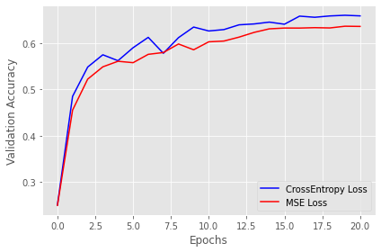

```python
print_result(nn_cross,num_df.to_numpy(), y_train.to_numpy(),num_test.to_numpy(),y_test.to_numpy(),title="CrossEntropy Loss",color="blue")
print_result(nn_mse,num_df.to_numpy(), y_train.to_numpy(),num_test.to_numpy(),y_test.to_numpy(),title="MSE Loss",color="red")
```

As you can see, without these categorical variables our accuracy is much more reasonable.

```python
one_df = pd.get_dummies(df,columns=['State','County'])
X_train, X_test, y_train, y_test = train_test_split(one_df, target, test_size=0.20,stratify=target, random_state=42)

num_df = pd.concat([X_train.pop(x) for x in num_var], axis=1)
num_test = pd.concat([X_test.pop(x) for x in num_var], axis=1)

mmscaler = MinMaxScaler()
num_df = pd.DataFrame(mmscaler.fit_transform(num_df),columns=num_var)
num_test = pd.DataFrame(mmscaler.transform(num_test),columns=num_var)
X_train.reset_index(inplace=True)
X_test.reset_index(inplace=True)
X_train = pd.concat([num_df,X_train] , axis=1)
X_test = pd.concat([num_test,X_test] , axis=1)


vals = { 'n_hidden':30,
         'C':0.01, 'epochs':50, 'eta':0.1, # poor starting learning rate!!
         'alpha':0.001, 'decrease_const':0.1, 'decrease_iter':15,
         'minibatches':50,
         'shuffle':True}

nn_cross = TLPBetterInitialCrossEntropy(**vals)
nn_mse = TLPBetterInitialMSE(**vals)

%time nn_cross.fit(X_train.to_numpy(), y_train.to_numpy(), print_progress=1, XY_test=(X_test.to_numpy(), y_test.to_numpy()))
%time nn_mse.fit(X_train.to_numpy(), y_train.to_numpy(), print_progress=1, XY_test=(X_test.to_numpy(), y_test.to_numpy()))
```

```
Epoch: 50/50
```

```
CPU times: user 2min 57s, sys: 31.9 s, total: 3min 29s
Wall time: 1min 9s
```

```
Epoch: 50/50
```

```
CPU times: user 2min 58s, sys: 32.4 s, total: 3min 30s
Wall time: 1min 13s
```

```
<__main__.TLPBetterInitialMSE at 0x7f94fa38bb50>
```

```
=================
CrossEntropy Loss :
Resubstitution acc: 0.25069618730016846
Validation acc: 0.2506875687568757
=================
MSE Loss :
Resubstitution acc: 0.24956165984804207
Validation acc: 0.2495874587458746
```

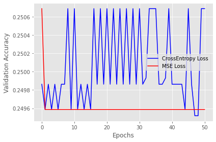

```python
print_result(nn_cross,X_train.to_numpy(), y_train.to_numpy(),X_test.to_numpy(),y_test.to_numpy(),title="CrossEntropy Loss",color="blue")
print_result(nn_mse,X_train.to_numpy(), y_train.to_numpy(),X_test.to_numpy(),y_test.to_numpy(),title="MSE Loss",color="red")
```

X_train showing correct preprocessing for method 3.

```python
X_train
```

|  | TotalPop | Men | Women | Hispanic | White | Black | Native | Asian | Pacific | VotingAgeCitizen | Income | IncomeErr | IncomePerCap | IncomePerCapErr | Poverty | Professional | Service | Office | Construction | Production | ... | County_1935 | County_1936 | County_1937 | County_1938 | County_1939 | County_1940 | County_1941 | County_1942 | … |
| --- | --- | --- | --- | --- | --- | --- | --- | --- | --- | --- | --- | --- | --- | --- | --- | --- | --- | --- | --- | --- | --- | --- | --- | --- | --- | --- | --- | --- | --- | --- |
| 0 | 0.043211 | 0.043424 | 0.043061 | 0.054 | 0.899 | 0.000 | 0.019115 | 0.008753 | 0.000000 | 0.059341 | 0.193655 | 0.089277 | 0.119774 | 0.045775 | 0.146 | 0.208243 | 0.351199 | 0.417763 | 0.214391 | 0.273196 | ... | 0 | 0 | 0 | 0 | 0 | 0 | 0 | 0 | … |
| 1 | 0.048679 | 0.044262 | 0.053021 | 0.056 | 0.704 | 0.172 | 0.001006 | 0.032823 | 0.000000 | 0.068947 | 0.131499 | 0.021112 | 0.116639 | 0.030073 | 0.181 | 0.473970 | 0.280677 | 0.402961 | 0.046990 | 0.149485 | ... | 0 | 0 | 0 | 0 | 0 | 0 | 0 | 0 | … |
| 2 | 0.024026 | 0.026582 | 0.021606 | 0.026 | 0.431 | 0.494 | 0.010060 | 0.020788 | 0.000000 | 0.031894 | 0.242336 | 0.200991 | 0.137114 | 0.060181 | 0.186 | 0.567245 | 0.148096 | 0.335526 | 0.038179 | 0.243986 | ... | 0 | 0 | 0 | 0 | 0 | 0 | 0 | 0 | … |
| 3 | 0.136459 | 0.143828 | 0.129363 | 0.549 | 0.152 | 0.059 | 0.006036 | 0.226477 | 0.033380 | 0.095149 | 0.191004 | 0.095758 | 0.072159 | 0.029561 | 0.255 | 0.190889 | 0.252468 | 0.513158 | 0.080764 | 0.477663 | ... | 0 | 0 | 0 | 0 | 0 | 0 | 0 | 0 | … |
| 4 | 0.011196 | 0.010422 | 0.012006 | 0.068 | 0.078 | 0.853 | 0.000000 | 0.000000 | 0.000000 | 0.010496 | 0.072343 | 0.051338 | 0.032823 | 0.028645 | 0.653 | 0.159436 | 0.218618 | 0.404605 | 0.227606 | 0.512027 | ... | 0 | 0 | 0 | 0 | 0 | 0 | 0 | 0 | … |
| ... | ... | ... | ... | ... | ... | ... | ... | ... | ... | ... | ... | ... | ... | ... | ... | ... | ... | ... | ... | ... | ... | ... | ... | ... | ... | ... | ... | ... | ... | … |
| 58169 | 0.113197 | 0.110267 | 0.116093 | 0.263 | 0.355 | 0.223 | 0.000000 | 0.137856 | 0.002782 | 0.131083 | 0.423212 | 0.213266 | 0.156093 | 0.045216 | 0.110 | 0.373102 | 0.349788 | 0.406250 | 0.126285 | 0.128866 | ... | 0 | 0 | 0 | 0 | 0 | 0 | 0 | 0 | … |
| 58170 | 0.038231 | 0.037779 | 0.038728 | 0.289 | 0.552 | 0.056 | 0.025151 | 0.055799 | 0.000000 | 0.044016 | 0.285488 | 0.075418 | 0.120565 | 0.028467 | 0.043 | 0.313449 | 0.227080 | 0.333882 | 0.221733 | 0.335052 | ... | 0 | 0 | 0 | 0 | 0 | 0 | 0 | 0 | … |
| 58171 | 0.081976 | 0.082258 | 0.081759 | 0.063 | 0.676 | 0.025 | 0.000000 | 0.190372 | 0.000000 | 0.103891 | 0.650746 | 0.223964 | 0.379929 | 0.097320 | 0.051 | 0.771150 | 0.136812 | 0.266447 | 0.013216 | 0.036082 | ... | 0 | 0 | 0 | 0 | 0 | 0 | 0 | 0 | … |
| 58172 | 0.068688 | 0.070347 | 0.067134 | 0.265 | 0.717 | 0.000 | 0.004024 | 0.003282 | 0.000000 | 0.077766 | 0.250030 | 0.090417 | 0.138707 | 0.027801 | 0.152 | 0.428416 | 0.203103 | 0.282895 | 0.262849 | 0.187285 | ... | 0 | 0 | 0 | 0 | 0 | 0 | 0 | 0 | … |
| 58173 | 0.052070 | 0.048480 | 0.055609 | 0.123 | 0.776 | 0.027 | 0.000000 | 0.066740 | 0.000000 | 0.065008 | 0.368569 | 0.136917 | 0.184290 | 0.050260 | 0.086 | 0.495662 | 0.244006 | 0.373355 | 0.067548 | 0.166667 | ... | 0 | 0 | 0 | 0 | 0 | 0 | 0 | 0 | … |

58174 rows × 2040 columns

After one hot encoding label data and normalizing continuous variables, we still do not see much improvment. Therefore, we need to try a better strategy for encoding or changing the categorical variable to the real world continuous variable. One idea is to look up latitude and lontitude of the county and use those instead of county and and state name. We should also carry out hyperparameter optimization to actually know if we can get good separation using this method, even though hyperparameter optimization is beyond the scope of this assignment.

```python
distdf = pd.read_csv('county.csv')
```

```
Epoch: 2/200
```

```
CPU times: user 6.68 s, sys: 1.06 s, total: 7.75 s
Wall time: 2.02 s
```

```
Epoch: 20/20
```

```
CPU times: user 6.2 s, sys: 948 ms, total: 7.15 s
Wall time: 1.82 s
=================
CrossEntropy Loss :
Resubstitution acc: 0.6532299652765841
Validation acc: 0.651471397139714
=================
MSE Loss :
Resubstitution acc: 0.6179908550211435
Validation acc: 0.619430693069307
```

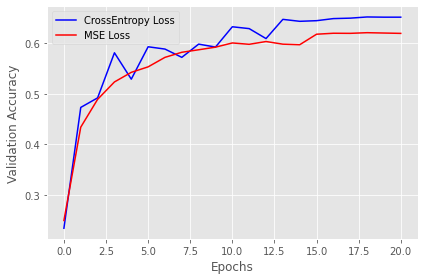

```python
ChildPoverty = distdf.ChildPoverty
ChildPoverty_incode = pd.cut(ChildPoverty,bins_,labels=False)
distdf['ChildPoverty_'] = ChildPoverty_incode
# normalize continuous data ONLY
num_var = ['latitude','longitude','TotalPop', 'Men', 'Women', 'Hispanic', 'White','Black', 'Native', 'Asian', 'Pacific', 'VotingAgeCitizen', 'Income','IncomeErr', 'IncomePerCap', 'IncomePerCapErr', 'Poverty','Professional', 'Service', 'Office', 'Construction', 'Production','Drive', 'Carpool', 'Transit', 'Walk', 'OtherTransp', 'WorkAtHome','MeanCommute', 'Employed', 'PrivateWork', 'PublicWork', 'SelfEmployed','FamilyWork', 'Unemployment']

X_train, X_test, y_train, y_test = train_test_split(distdf[num_var], distdf['ChildPoverty_'], test_size=0.20,stratify=target, random_state=42)


mmscaler = MinMaxScaler()
num_df = pd.DataFrame(mmscaler.fit_transform(X_train[num_var]),columns=num_var)
# num_df['State'] = X_train.pop("State")
# num_df['County'] = X_train.pop("County")

vals = { 'n_hidden':30,
         'C':0.1, 'epochs':20, 'eta':0.001, # poor starting learning rate!!
         'alpha':0.001, 'decrease_const':0.1, 'decrease_iter':15,
         'minibatches':50,
         'shuffle':True}

nn_cross = TLPBetterInitialCrossEntropy(**vals)
nn_mse = TLPBetterInitialMSE(**vals)
num_test = mmscaler.transform(X_test[num_var])
num_test=pd.DataFrame(num_test,columns=num_var)
# num_test['State'] = X_test.pop('State')
# num_test['County'] = X_test.pop('County')

%time nn_cross.fit(num_df.to_numpy(), y_train.to_numpy(), print_progress=1, XY_test=(num_test.to_numpy(), y_test.to_numpy()))
%time nn_mse.fit(num_df.to_numpy(), y_train.to_numpy(), print_progress=1, XY_test=(num_test.to_numpy(), y_test.to_numpy()))
print_result(nn_cross,num_df.to_numpy(), y_train.to_numpy(),num_test.to_numpy(),y_test.to_numpy(),title="CrossEntropy Loss",color="blue")
print_result(nn_mse,num_df.to_numpy(), y_train.to_numpy(),num_test.to_numpy(),y_test.to_numpy(),title="MSE Loss",color="red")
```

```python
num_df
```

|  | latitude | longitude | TotalPop | Men | Women | Hispanic | White | Black | Native | Asian | Pacific | VotingAgeCitizen | Income | IncomeErr | IncomePerCap | IncomePerCapErr | Poverty | Professional | Service | Office | Construction | Production | Drive | Carpool | Transit | Walk | OtherTransp | WorkAtHome | MeanCommute | … |
| --- | --- | --- | --- | --- | --- | --- | --- | --- | --- | --- | --- | --- | --- | --- | --- | --- | --- | --- | --- | --- | --- | --- | --- | --- | --- | --- | --- | --- | --- | --- |
| 0 | 0.524760 | 0.208880 | 0.046785 | 0.043952 | 0.049677 | 0.068 | 0.733 | 0.095 | 0.000000 | 0.062361 | 0.000000 | 0.061476 | 0.288195 | 0.054829 | 0.200954 | 0.035509 | 0.047 | 0.498915 | 0.200282 | 0.356846 | 0.093750 | 0.127273 | 0.822 | 0.156522 | 0.038546 | 0.016731 | 0.017822 | 0.038647 | 0.317073 | … |
| 1 | 0.534138 | 0.124894 | 0.053857 | 0.051520 | 0.056266 | 0.033 | 0.819 | 0.020 | 0.002012 | 0.110245 | 0.000000 | 0.074004 | 0.327316 | 0.066262 | 0.271297 | 0.097796 | 0.075 | 0.689805 | 0.129760 | 0.315353 | 0.019345 | 0.051240 | 0.784 | 0.076522 | 0.046256 | 0.042471 | 0.031683 | 0.097826 | 0.326829 | … |
| 2 | 0.439959 | 0.265627 | 0.038628 | 0.037159 | 0.040199 | 0.047 | 0.002 | 0.911 | 0.000000 | 0.044543 | 0.000000 | 0.043127 | 0.222567 | 0.036230 | 0.103634 | 0.026789 | 0.110 | 0.328633 | 0.376587 | 0.243430 | 0.186012 | 0.213223 | 0.312 | 0.146087 | 0.646476 | 0.000000 | 0.015842 | 0.010870 | 0.663415 | … |
| 3 | 0.351701 | 0.201796 | 0.020284 | 0.017122 | 0.023499 | 0.017 | 0.139 | 0.736 | 0.019115 | 0.000000 | 0.000000 | 0.027879 | 0.116685 | 0.008569 | 0.083124 | 0.022911 | 0.262 | 0.257050 | 0.321580 | 0.366528 | 0.108631 | 0.325620 | 0.873 | 0.147826 | 0.011013 | 0.000000 | 0.000000 | 0.037440 | 0.229268 | … |
| 4 | 0.009716 | 0.288379 | 0.029632 | 0.027233 | 0.032105 | 0.945 | 0.033 | 0.007 | 0.000000 | 0.016704 | 0.000000 | 0.042110 | 0.045180 | 0.020080 | 0.070463 | 0.106028 | 0.565 | 0.372017 | 0.260931 | 0.578147 | 0.063988 | 0.019835 | 0.640 | 0.097391 | 0.074890 | 0.227799 | 0.061386 | 0.035024 | 0.396748 | … |
| ... | ... | ... | ... | ... | ... | ... | ... | ... | ... | ... | ... | ... | ... | ... | ... | ... | ... | ... | ... | ... | ... | ... | ... | ... | ... | ... | ... | ... | ... | … |
| 58169 | 0.356463 | 0.146127 | 0.032045 | 0.033933 | 0.030360 | 0.477 | 0.369 | 0.121 | 0.000000 | 0.012249 | 0.009901 | 0.024118 | 0.153632 | 0.054279 | 0.072048 | 0.020033 | 0.249 | 0.165944 | 0.534556 | 0.340249 | 0.172619 | 0.175207 | 0.742 | 0.246957 | 0.069383 | 0.015444 | 0.067327 | 0.009662 | 0.356098 | … |
| 58170 | 0.399034 | 0.229186 | 0.045991 | 0.043859 | 0.048202 | 0.044 | 0.856 | 0.062 | 0.002012 | 0.011136 | 0.000000 | 0.056952 | 0.124380 | 0.015828 | 0.101934 | 0.045561 | 0.191 | 0.315618 | 0.418900 | 0.199170 | 0.141369 | 0.284298 | 0.784 | 0.179130 | 0.000000 | 0.073359 | 0.025743 | 0.050725 | 0.216260 | … |
| 58171 | 0.419857 | 0.260651 | 0.071483 | 0.069045 | 0.073988 | 0.014 | 0.846 | 0.086 | 0.002012 | 0.017817 | 0.000000 | 0.091743 | 0.418469 | 0.075650 | 0.197897 | 0.048059 | 0.059 | 0.489154 | 0.225670 | 0.272476 | 0.174107 | 0.123967 | 0.882 | 0.071304 | 0.013216 | 0.006435 | 0.011881 | 0.064010 | 0.406504 | … |
| 58172 | 0.455036 | 0.243143 | 0.034627 | 0.027512 | 0.041673 | 0.041 | 0.493 | 0.431 | 0.000000 | 0.035635 | 0.000000 | 0.044804 | 0.173959 | 0.092121 | 0.106456 | 0.037389 | 0.137 | 0.272234 | 0.428773 | 0.240664 | 0.120536 | 0.314050 | 0.889 | 0.093913 | 0.031938 | 0.001287 | 0.000000 | 0.033816 | 0.307317 | … |
| 58173 | 0.054176 | 0.026398 | 0.133664 | 0.138586 | 0.129021 | 0.114 | 0.335 | 0.000 | 0.000000 | 0.281737 | 0.117162 | 0.177057 | 0.315420 | 0.051049 | 0.152850 | 0.033273 | 0.077 | 0.299349 | 0.272214 | 0.327801 | 0.288690 | 0.165289 | 0.845 | 0.147826 | 0.006608 | 0.003861 | 0.047525 | 0.045894 | 0.367480 | … |

58174 rows × 35 columns

So, we see using latitude and longitude give a comparable result as using only the numerical varaibels.

**Analysis**

Next up is modeling 3 layer, 4 layer, and 5 layer networks, along with an adaptive learning technique.

# Modeling

```python
# 3 layer
class ThreeLayerPerceptronBase(object):
    def __init__(self, n_hidden=15, n_hidden2 = 30,
                 C=0.0, epochs=500, eta=0.001, random_state=None):
        np.random.seed(random_state)
        self.n_hidden = n_hidden
        self.n_hidden2 = n_hidden2
        self.l2_C = C
        self.epochs = epochs
        self.eta = eta

    @staticmethod
    def _encode_labels(y):
        """Encode labels into one-hot representation"""
        onehot = pd.get_dummies(y).values.T

        return onehot

    def _initialize_weights(self):
        """Initialize weights with small random numbers."""
        W1_num_elems = (self.n_features_)*self.n_hidden2
        W1 = np.random.uniform(-1.0, 1.0, size=W1_num_elems)
        W1 = W1.reshape(self.n_hidden2, self.n_features_) # reshape to be W
        b1 = np.zeros((self.n_hidden2, 1))

        W2_num_elems = (self.n_hidden2)*self.n_hidden
        W2 = np.random.uniform(-1.0, 1.0, size=W2_num_elems)
        W2 = W2.reshape(self.n_hidden, self.n_hidden2)
        b2 = np.zeros((self.n_hidden, 1))

        W3_num_elems = (self.n_hidden)*self.n_output_
        W3 = np.random.uniform(-1.0, 1.0, size=W3_num_elems)
        W3 = W3.reshape(self.n_output_, self.n_hidden)
        b3 = np.zeros((self.n_output_, 1))

        return W1, W2, W3, b1, b2, b3

    @staticmethod
    def _sigmoid(z):
        """Use scipy.special.expit to avoid overflow"""
        # 1.0 / (1.0 + np.exp(-z))
        return expit(z)


    @staticmethod
    def _L2_reg(lambda_, W1, W2, W3):
        """Compute L2-regularization cost"""
        # only compute for non-bias terms
        return (lambda_/2.0) * np.sqrt(np.mean(W1[:, 1:] ** 2) + np.mean(W2[:, 1:] ** 2) + np.mean(W3[:, 1:] ** 2))

    def _cost(self,A3,Y_enc,W1,W2, W3):
        '''Get the objective function value'''
        cost = np.mean((Y_enc-A3)**2)
        L2_term = self._L2_reg(self.l2_C, W1, W2, W3)
        return cost + L2_term

    def _feedforward(self, X, W1, W2, W3, b1, b2, b3):
        """Compute feedforward step
        -----------
        X : Input layer with original features.
        W1: Weight matrix for input layer -> hidden layer.
        W2: Weight matrix for hidden layer -> output layer.
        ----------
        a1-a3 : activations into layer (or output layer)
        z1-z2 : layer inputs

        """
        A1 = X.T
        Z1 = W1 @ A1 + b1
        A2 = self._sigmoid(Z1)
        Z2 = W2 @ A2 + b2
        A3 = self._sigmoid(Z2)
        Z3 = W3 @ A3 + b3
        A4 = self._sigmoid(Z3)
        return A1, Z1, A2, Z2, A3, Z3, A4

    def _get_gradient(self, A1, A2, A3, A4, Z1, Z2, Z3, Y_enc, W1, W2, W3):
        """ Compute gradient step using backpropagation.
        """
        # vectorized backpropagation
        V3 = -2*(Y_enc-A4)*A4*(1-A4)
        V2 = A3*(1-A3)*(W3.T @ V3)
        V1 = A2*(1-A2)*(W2.T @ V2)

        gradW2 = V2 @ A2.T
        gradW1 = V1 @ A1.T
        gradW3 = V3 @ A3.T

        gradb2 = np.sum(V2, axis=1).reshape((-1,1))
        gradb1 = np.sum(V1, axis=1).reshape((-1,1))
        gradb3 = np.sum(V3, axis=1).reshape((-1,1))


        # regularize weights that are not bias terms
        gradW1 += W1 * self.l2_C
        gradW2 += W2 * self.l2_C
        gradW3 += W3 * self.l2_C

        return gradW1, gradW2, gradW3, gradb1, gradb2, gradb3

    def predict(self, X):
        """Predict class labels"""
        _, _, _, _, _, _, A4 = self._feedforward(X, self.W1, self.W2, self.W3, self.b1, self.b2, self.b3)
        y_pred = np.argmax(A4, axis=0)
        return y_pred
```

```python
from sklearn.metrics import accuracy_score
# just start with the vectorized version and minibatch
class TLPMiniBatch(ThreeLayerPerceptronBase):  #MSE loss
    def __init__(self, alpha=0.0, decrease_const=0.1,
                 decrease_iter = 10, shuffle=True,
                 minibatches=1,save_grad={}, **kwds):
        # need to add to the original initializer
        self.alpha = alpha
        self.decrease_const = decrease_const
        self.decrease_iter = decrease_iter
        self.shuffle = shuffle
        self.minibatches = minibatches
        self.save_grad = save_grad
        # but keep other keywords
        super().__init__(**kwds)


    def fit(self, X, y, print_progress=False, XY_test=None):
        """ Learn weights from training data. With mini-batch"""
        X_data, y_data = X.copy(), y.copy()
        Y_enc = self._encode_labels(y)

        # init weights and setup matrices
        self.n_features_ = X_data.shape[1]
        self.n_output_ = Y_enc.shape[0]
        self.W1, self.W2, self.W3, self.b1, self.b2, self.b3 = self._initialize_weights()

        # start momentum at zero for previous updates
        rho_W1_prev = np.zeros(self.W1.shape) # for momentum
        rho_W2_prev = np.zeros(self.W2.shape) # for momentum
        rho_W3_prev = np.zeros(self.W3.shape)

        self.cost_ = []
        self.score_ = []
        # get starting acc
        self.score_.append(accuracy_score(y_data,self.predict(X_data)))

        # keep track of validation, if given
        if XY_test is not None:
            X_test = XY_test[0].copy()
            y_test = XY_test[1].copy()
            self.val_score_ = []
            self.val_score_.append(accuracy_score(y_test,self.predict(X_test)))
            self.val_cost_ = []
        self.save_grad = {}

        for i in range(self.epochs):

            # adaptive learning rate
            # decrease at certain epochs
            eta = self.eta * self.decrease_const**(np.floor(i/self.decrease_iter))

            if print_progress>0 and (i+1)%print_progress==0:
                sys.stderr.write('\rEpoch: %d/%d' % (i+1, self.epochs))
                sys.stderr.flush()

            if self.shuffle:
                idx_shuffle = np.random.permutation(y_data.shape[0])
                X_data, Y_enc, y_data = X_data[idx_shuffle], Y_enc[:, idx_shuffle], y_data[idx_shuffle]

            mini = np.array_split(range(y_data.shape[0]), self.minibatches)
            mini_cost = []
            for idx in mini:

                # feedforward
                A1, Z1, A2, Z2, A3, Z3, A4 = self._feedforward(X_data[idx],
                                                       self.W1,
                                                       self.W2,
                                                       self.W3,
                                                       self.b1,
                                                       self.b2,
                                                       self.b3
                                                      )

                cost = self._cost(A4,Y_enc[:, idx],self.W1,self.W2, self.W3)
                mini_cost.append(cost) # this appends cost of mini-batch only

                # compute gradient via backpropagation
                gradW1, gradW2, gradW3, gradb1, gradb2, gradb3 = self._get_gradient(A1=A1, A2=A2, A3=A3, A4=A4,
                                                                                    Z1=Z1, Z2=Z2, Z3=Z3,
                                                                                      Y_enc=Y_enc[:, idx],
                                                                                      W1=self.W1,W2=self.W2,W3=self.W3)
                self.save_grad[i] = [np.mean(gradb1), np.mean(gradb2), np.mean(gradb3)]
                # momentum calculations
                rho_W1, rho_W2, rho_W3 = eta * gradW1, eta * gradW2, eta * gradW3
                self.W1 -= (rho_W1 + (self.alpha * rho_W1_prev)) # update with momentum
                self.W2 -= (rho_W2 + (self.alpha * rho_W2_prev)) # update with momentum
                self.W3 -= (rho_W3 + (self.alpha * rho_W3_prev)) # update with momentum
                self.b1 -= eta * gradb1
                self.b2 -= eta * gradb2
                self.b3 -= eta * gradb3
                rho_W1_prev, rho_W2_prev, rho_W3_prev = rho_W1, rho_W2, rho_W3


            self.cost_.append(np.mean(mini_cost))
            self.score_.append(accuracy_score(y_data,self.predict(X_data)))
            if XY_test is not None:
                yhat = self.predict(X_test)
                self.val_score_.append(accuracy_score(y_test,yhat))

        return self
```